# Untitled

https://blogs.rstudio.com/tensorflow/posts/2019-07-31-censored-data/ https://cloud.r-project.org/web/views/Survival.html https://www.gormanalysis.com/blog/r-data-table-rolling-joins/ https://eranraviv.com/bootstrapping-time-series-r-code/

```r
library(data.table)
library(ggplot2)
```

```r
dt <- fread("data/orders.csv",
            header = FALSE,
            col.names = c("date_create", "id_lead", "date_approve",
                          "date_call", "id_webmaster", "product",
                          "op_login", "op_gender", "op_age", "op_country"),
            na.strings = c("", "\\N"))
# Stopped early on line 2194779. Expected 10 fields but found 12. Consider fill=TRUE and comment.char=. First discarded non-empty line: <<"2019-04-05 04:56:37","13950334","2019-04-05 17:13:53","2019-04-05 17:06:28",\N,"Titan Gel","GTOP1AM-236","",\N,"Guatemala",\N,"309">>

# Пропускаем оставшиеся строки (примерно 10 шт.)

#d <- read.csv("data/orders.csv", header = FALSE)
```

```r
dt[, `:=`(date_create = as.POSIXct(date_create,
                                   format = "%Y-%m-%d %H:%M:%S",
                                   optional = TRUE),
          date_approve = as.POSIXct(date_approve,
                                    format = "%Y-%m-%d %H:%M:%S",
                                    optional = TRUE),
          date_call = as.POSIXct(date_call,
                                 format = "%Y-%m-%d %H:%M:%S",
                                 optional = TRUE))]
```

Отберем наблюдения, для которых указана дата звонка оператора. Все остальные клиенты подтвердили или не подтвердили заказ самостоятельно и с точки зрения оценки работы операторов интереса не представляют. Также для некоторых строк проставлена информарция об операторе, но нет даты звонка; такие строки тоже не представляют интереса.

```r
dt2 <- dt[!is.na(date_call), ]
dt2[, .N]
```

```
## [1] 711170
```

Всего таких наблюдений ~700 тыс. - треть от общего количества.

```r
dt2[is.na(date_approve), .N]
```

[output not shown]

```r
dt2[, n_ops := uniqueN(op_login), by = id_lead]
table(dt2[, n_ops])
```

```
##
##      1      2      3      4      5      6      7      8      9     10
## 258693 113106  81340  65845  52019  41961  33502  25745  17522  10318
##     11     12     13     14     15     16     18
##   6252   2864   1206    545    171     59     22
```

Есть лиды, которым звонили до 18 разных операторов. Рассмотрим один такой лид:

```r
dt2[n_ops == 18, ]
```

```
##             date_create  id_lead        date_approve           date_call
##  1: 2018-11-25 21:18:49 42359425 2019-05-26 01:35:07 2018-11-25 21:20:51
##  2: 2018-11-25 21:18:49 42359425 2019-05-26 01:35:07 2018-11-25 21:20:59
##  3: 2018-11-25 21:18:49 42359425 2019-05-26 01:35:07 2018-11-29 02:06:20
##  4: 2018-11-25 21:18:49 42359425 2019-05-26 01:35:07 2018-11-29 02:29:35
##  5: 2018-11-25 21:18:49 42359425 2019-05-26 01:35:07 2018-11-30 18:49:02
##  6: 2018-11-25 21:18:49 42359425 2019-05-26 01:35:07 2018-11-30 20:45:30
##  7: 2018-11-25 21:18:49 42359425 2019-05-26 01:35:07 2018-11-30 20:45:50
##  8: 2018-11-25 21:18:49 42359425 2019-05-26 01:35:07 2018-12-01 22:09:15
##  9: 2018-11-25 21:18:49 42359425 2019-05-26 01:35:07 2018-12-02 23:16:15
## 10: 2018-11-25 21:18:49 42359425 2019-05-26 01:35:07 2018-12-02 23:36:16
## 11: 2018-11-25 21:18:49 42359425 2019-05-26 01:35:07 2018-12-03 01:05:15
## 12: 2018-11-25 21:18:49 42359425 2019-05-26 01:35:07 2018-12-20 01:27:11
## 13: 2018-11-25 21:18:49 42359425 2019-05-26 01:35:07 2019-01-18 00:57:37
## 14: 2018-11-25 21:18:49 42359425 2019-05-26 01:35:07 2019-01-18 00:57:47
```

[output cut: 57 more lines]

Построим промежуточную таблицу с бинарным откликом с расчетными параметрами чтобы для каждого лида и оператора расчитать вероятности

```r
# Убираем строки без date_create
dt2 <- dt2[!is.na(date_create), ]

# Сортируем таблицу по id_lead и по дате звонка внутри каждого лида
setkey(dt2, id_lead, date_call)

# Добавляем идентификатор того, что после данного звонка
# произошло подтверждение заказа
dt2[, is_approved_after_call := 0]
dt2[dt2[, .I[.N], by = id_lead]$V1, # строки для замены
    is_approved_after_call := 1]
```

Проверяем, все ли даты последнего звонка для данного лида предшествуют дате подтверждения

```r
dt2[is_approved_after_call == 1 & date_call > date_approve, ]
```

```
##            date_create  id_lead        date_approve           date_call
## 1: 2019-01-05 17:38:25 44599809 2019-02-28 11:00:54 2019-04-01 10:00:52
## 2: 2019-01-28 08:35:24 45818268 2019-01-28 08:55:37 2019-03-25 15:27:23
## 3: 2019-02-21 21:10:56 47096940 2019-02-22 06:39:59 2019-04-01 10:03:33
## 4: 2019-02-26 10:26:24 47320171 2019-02-26 11:03:44 2019-04-01 10:58:50
## 5: 2019-02-26 18:57:18 47341530 2019-02-27 05:36:10 2019-04-01 13:00:14
## 6: 2019-02-26 23:41:35 47352668 2019-02-27 07:27:34 2019-04-01 10:30:45
## 7: 2019-02-28 10:38:15 47421603 2019-02-28 10:58:03 2019-04-01 12:59:20
## 8: 2019-03-01 19:39:18 47495170 2019-03-02 05:54:58 2019-04-01 13:53:43
## 9: 2019-04-12 04:29:08 49508145 2019-05-16 08:46:15 2019-05-16 08:46:26
##    id_webmaster                product     op_login op_gender op_age
## 1:        33834 Ecoslim (effervescent) THOP1PM-1268    female     32
## 2:          430              Titan Gel THOP1PM-1268    female     32
## 3:        16049 Ecoslim (effervescent) THOP1PM-1585    female     29
## 4:        36889 Ecoslim (effervescent) THOP1AM-1477      male     35
## 5:        13088                XTRAZEX THOP1PM-1268    female     32
## 6:        14870              Titan Gel THOP1PM-1268    female     32
## 7:        37150              Titan Gel THOP1PM-1585    female     29
## 8:        14870              Titan Gel THOP1PM-1588      male     25
## 9:        39813 Ecoslim (effervescent)  THOP1AM-299               35
##    op_country n_ops is_approved_after_call
## 1:   Thailand     1                      1
## 2:   Thailand     1                      1
## 3:   Thailand     1                      1
## 4:   Thailand     1                      1
## 5:   Thailand     1                      1
## 6:   Thailand     1                      1
## 7:   Thailand     1                      1
## 8:   Thailand     1                      1
## 9:   Thailand     2                      1
```

```r
# Empty data.table (0 rows and 12 cols)
```

Предобработка данных:

```r
# Кодируем NA и "" в op_gender как отдельную категорию
dt2[is.na(op_gender) | op_gender == "", op_gender := "unknown"]

dt2[, unique(op_age)]
```

```
##  [1]  25  20  28  30  23  21  56  29  19  38  42  26  22  27  33  58  24
## [18]  39  35  32  43  51  36  40  18  NA  31  34  47  37  45  46  41  44
## [35]  50  59  48  49 -71
```

```r
# [1]  25  20  28  30  23  21  56  29  19  38  42  26  22  27  33  58  24  39  35  32  43  51
# [23]  36  40  18  NA  31  34  47  37  45  46  41  44  50  59  48  49 -71

# -71 в op_age меняем на NA
dt2[op_age == -71, op_age := NA]

# Добавляем количество звонков, предшествующих данному
dt2[, n_calls_before := dt2[, .SD[, .I], by = id_lead]$V1 - 1]

# Добавляем логарифм времени в часах от момента регистрации до звонка
dt2[, time_diff := log(as.numeric(difftime(date_call,
                                  date_create,
                                  units = "hours")))]

# Добавляем час звонка и час регистрации
# (время суток может быть важным предиктором)
dt2[, `:=`(hour_create = hour(date_create),
           hour_call = hour(date_call))]

# Удаляем пробелы в product
dt2[, product := gsub(pattern = "\\s", replacement = "", product)]
```

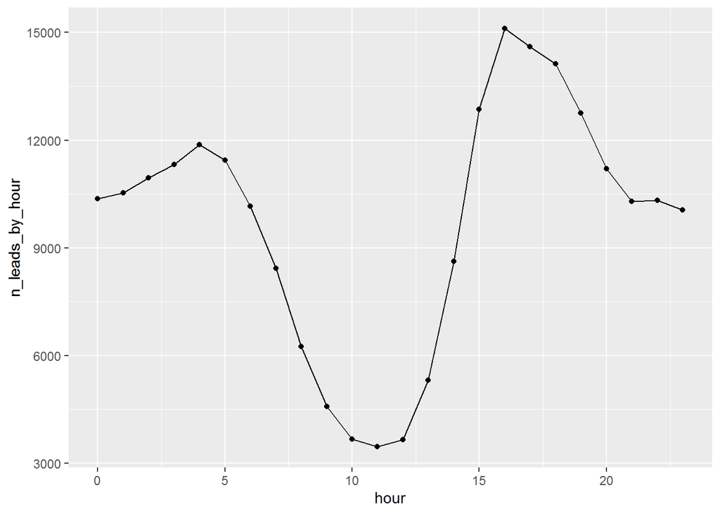

```r
dt2[, hour := hour(date_create)]
dt2[, n_leads_by_hour := uniqueN(id_lead), by = hour]

dt2[, day := yday(date_create)]
dt2[, n_leads_by_day := uniqueN(id_lead), by = day]

dt2[, year := year(date_create)]
dt2[, month := month(date_create)]
dt2[, mday := mday(date_create)]
dt2[, n_leads_by_year_day := uniqueN(id_lead), by = .(year, month, mday)]
dt2[, year_day := ISOdate(year, month, mday)]


ggplot(dt2[, .SD[1], by = hour], aes(hour, n_leads_by_hour)) +
  geom_point() +
  geom_line()
```

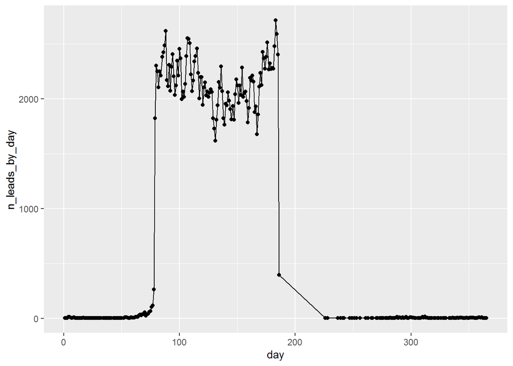

```r
ggplot(dt2[, .SD[1], by = day], aes(day, n_leads_by_day)) +
  geom_point() +
  geom_line()
```

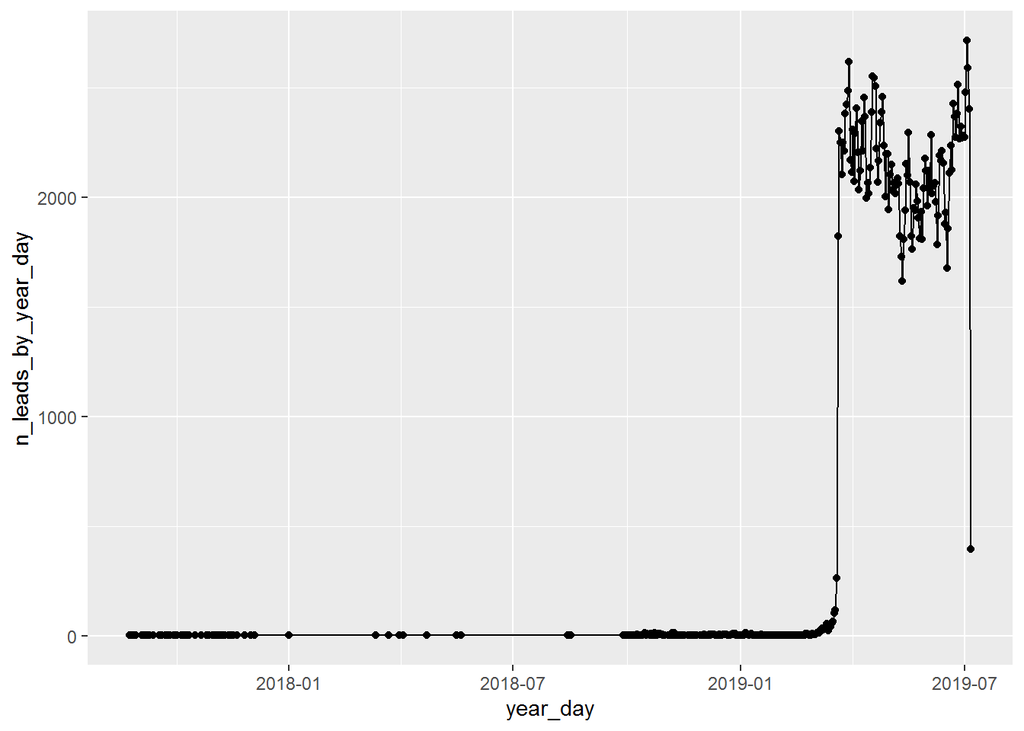

```r
ggplot(dt2[, .SD[1], by = .(year, month, mday)],
       aes(year_day, n_leads_by_year_day)) +
  geom_point() +
  geom_line()
```

Сохраняем получившуюся таблицу

```r
fwrite(dt2, "data/dt_processed.csv")
dt2 <- fread("data/dt_processed.csv")
```

## Модель для предсказания подтверждения после звонка

```r
# op_login пока не используем
dt_ml <- dt2[, .(product, op_gender, op_age, op_country,
                 n_calls_before, time_diff, hour_create, hour_call,
                 is_approved_after_call)]
factor_cols <- c("product", "op_gender", "op_country")
dt_ml[, (factor_cols) := lapply(.SD, as.factor), .SDcols = factor_cols]
dt_ml[, is_approved_after_call := factor(is_approved_after_call,
                                         levels = c(1, 0),
                                         labels = c("app", "non_app"))]

# Пока без импутации пропусков в op_age
tmp <- as.data.table(model.matrix(is_approved_after_call ~., dt_ml))
colnames(tmp) <- gsub(pattern = "[()]", replacement = "", colnames(tmp))
colnames(tmp) <- gsub(pattern = "\\'", replacement = "", colnames(tmp))
colnames(tmp) <- gsub(pattern = "-", replacement = "", colnames(tmp))
tmp[, is_approved_after_call := dt_ml[!is.na(op_age), is_approved_after_call]]
```

```r
# Ставить с гитхаба
# remotes::install_github("https://github.com/mlr-org/mlr3learners")
# remotes::install_github("https://github.com/mlr-org/mlr3viz")
# remotes::install_github("https://github.com/mlr-org/mlr3tuning")
# remotes::install_github("https://github.com/mlr-org/mlr3pipelines")
library(mlr3)
library(mlr3learners)
library(mlr3viz)
```

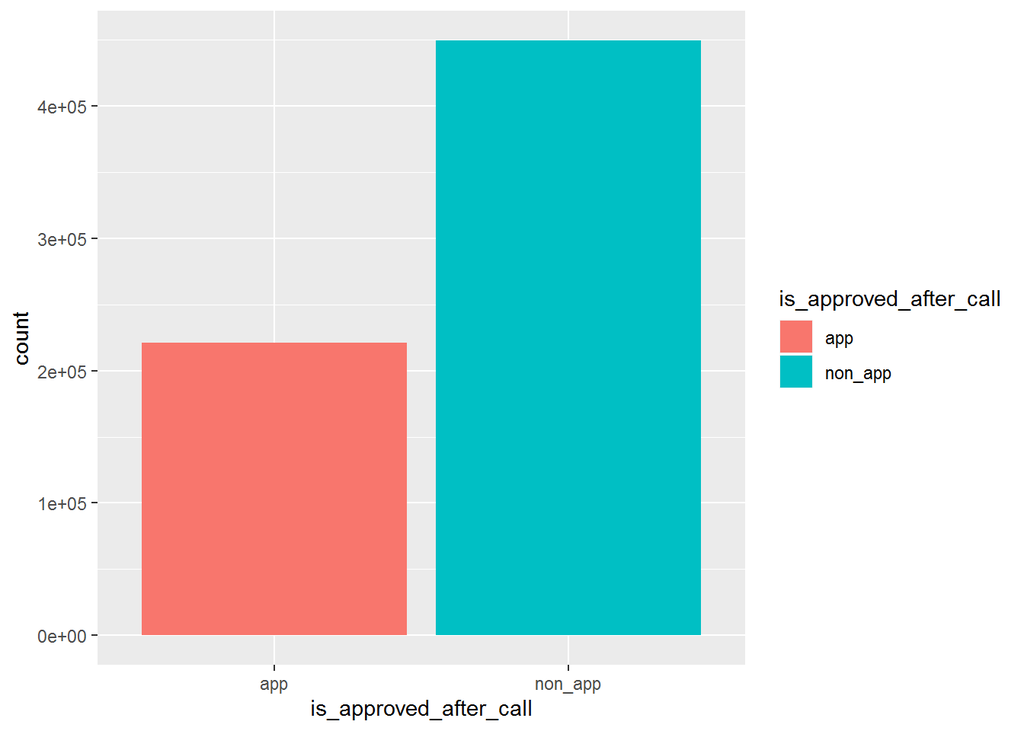

```r
task_logreg = TaskClassif$new(id = "logreg",
                              backend = tmp,
                              target = "is_approved_after_call")

autoplot(task_logreg)
```

```r
# Резервируем 20% строк для теста
set.seed(42)
train_set = sample(task_logreg$nrow, 0.8 * task_logreg$nrow)
test_set = setdiff(seq_len(task_logreg$nrow), train_set)
# test_rows <- sample(dt_ml[, .I], dt_ml[, .N] * 0.2)
# task_logreg$set_row_role(test_rows,
#                          new_roles = "validation",
#                          exclusive = TRUE)


learner = mlr_learners$get("classif.glmnet")

learner$train(task_logreg, row_ids = train_set)

print(learner$model)
```

```
## $lambda
##  [1] 0.0787851245 0.0717860712 0.0654087945 0.0595980575 0.0543035303
##  [6] 0.0494793544 0.0450837449 0.0410786293 0.0374293171 0.0341041997
## [11] 0.0310744766 0.0283139057 0.0257985764 0.0235067020 0.0214184314
## [16] 0.0195156769 0.0177819580 0.0162022579 0.0147628939 0.0134513991
## [21] 0.0122564139 0.0111675879 0.0101754901 0.0092715276 0.0084478707
## [26] 0.0076973851 0.0070135707 0.0063905044 0.0058227896 0.0053055090
## [31] 0.0048341822 0.0044047268 0.0040134230 0.0036568816 0.0033320143
## [36] 0.0030360073 0.0027662968 0.0025205466 0.0022966282 0.0020926021
## [41] 0.0019067011 0.0017373150 0.0015829767 0.0014423494 0.0013142151
## [46] 0.0011974638 0.0010910845 0.0009941555 0.0009058375 0.0008253654
## [51] 0.0007520422
##
## $cvm
##  [1] 1.268005 1.263287 1.259317 1.256013 1.253261 1.250969 1.249060
```

[output cut: 118 more lines]

```r
prediction = learner$predict(task_logreg, row_ids = test_set)
print(prediction)
```

```
## <PredictionClassif> for 134063 observations:
##         row_id   truth response
##      1:      3 non_app  non_app
##      2:      7 non_app  non_app
##      3:     16 non_app  non_app
##     ---
## 134061: 670294     app      app
## 134062: 670299     app      app
## 134063: 670301     app  non_app
```

```r
prediction$confusion
```

```
##          truth
## response    app non_app
##   app      1553    1028
##   non_app 42623   88859
```

```r
measure = mlr_measures$get("classif.acc")
prediction$score(measure)
```

[output not shown]

## Модель №2

```r
dt_ml <- dt2[, .(product, op_login, op_gender, op_age, op_country,
                 n_calls_before, time_diff, hour_create, hour_call,
                 is_approved_after_call)]
factor_cols <- c("product", "op_login", "op_gender", "op_country")
dt_ml[, (factor_cols) := lapply(.SD, as.factor), .SDcols = factor_cols]
dt_ml[, is_approved_after_call := factor(is_approved_after_call,
                                         levels = c(1, 0),
                                         labels = c("app", "non_app"))]
```

```r
library(rsample)
library(recipes)
library(purrr)
library(yardstick)
library(glmnet)
```

```r
set.seed(42)
data_split <- initial_split(dt_ml,
                            prop = 0.2,
                            strata = "is_approved_after_call")
train_data <- training(data_split)
test_data <- testing(data_split)
```

Создадим схему перекрестной проверки со стратифицированной по целевой переменной с разбивкой на 5 блоков:

```r
set.seed(42)
cv_splits <- vfold_cv(train_data, v = 5, strata = "is_approved_after_call")
```

Строить будем модель логистической регрессии (пакет **glmnet**), проверяя три значения гиперпараметра `lambda` (сила регуляризции) и три значения гиперпараметра `alpha` (пропорция l1- и l2-штрафов). Также проверим два варианта импутации пропусков в `op_age` (средним и медианой).

```r
param_grid <- expand.grid(imp_strategy = c("mean_imp", "median_imp"),
                          alpha = c(0, 0.5, 1),
                          lambda = c(0.1, 0.01, 0.001)
                          )
```

Нам понадобится функция, создающая “рецепт”, которая будет параметризована по типу импутации:

```r
create_recipe <- function(data = train_data,
                          imp_strategy = "mean_imp") {

  imp_methods <- list(mean_imp = step_meanimpute,
                      median_imp = step_medianimpute)

  rec_obj <- recipe(is_approved_after_call ~ ., data = data) %>%
    # Импутация средним или медианой для всех количественных
    imp_methods[[imp_strategy]](op_age) %>%
    # Преобразование Йео-Джонсона для всех количественных
    step_YeoJohnson(op_age, n_calls_before, time_diff,
                    hour_create, hour_call) %>%
    # Стандартизация
    step_center(op_age, n_calls_before, time_diff,
                hour_create, hour_call) %>%
    step_scale(op_age, n_calls_before, time_diff,
               hour_create, hour_call) %>%
    step_other(op_login) %>%
    step_dummy(product, op_login, op_gender, op_country, one_hot = TRUE)

  return(rec_obj)
}
```

Функция для обучения модели, возвращающая значение выбранной метрики (в данном случае accuracy):

```r
logreg_fit_pred <- function(split,
                            data = train_data,
                            imp_strategy = "mean_imp",
                            lambda = 0.1,
                            alpha = 0) {

  rec_obj <- create_recipe(data = data,
                           imp_strategy = imp_strategy)
  rec_obj <- prepper(split_obj = split, rec_obj, retain = FALSE)

  train <- bake(rec_obj,
                new_data = analysis(split),
                everything())
  val <- bake(rec_obj,
              new_data = assessment(split),
              everything())

  train_x <-
    train %>%
    select(-is_approved_after_call) %>%
    as.matrix()
  train_y <- train$is_approved_after_call

  val_x <- val %>%
    select(-is_approved_after_call) %>%
    as.matrix()
  val_y <- val$is_approved_after_call

  model <- glmnet(x = train_x,
                  y = train_y,
                  family = "binomial",
                  lambda = lambda,
                  alpha = alpha)

  preds <- predict(model,
                   type = "response",
                   newx = val_x)
  # for a factor, the last level in alphabetical order is the target class
  preds <- ifelse(preds > 0.5, 0, 1)
  preds <- factor(preds, levels = c(1, 0), labels = c("app", "non_app"))
  result <- accuracy(data.frame(preds = preds, val_y = val_y),
                     preds,
                     val_y)

  return(result)
}

logreg_fit_pred(cv_splits$splits[[1]], data = train_data)
```

```
## # A tibble: 1 x 3
##   .metric  .estimator .estimate
##   <chr>    <chr>          <dbl>
## 1 accuracy binary         0.679
```

Функция, обучающая модели для всех комбинаций значений гиперпараметров:

```r
across_grid <- function(split, grid) {
  metrics <- lapply(seq_len(nrow(grid)),
                    function(i) logreg_fit_pred(split,
                                                data = train_data,
                                                grid[i, "imp_strategy"],
                                                grid[i, "lambda"],
                                                grid[i, "alpha"]))
  result <- do.call(rbind, metrics)
  return(cbind(grid, result))
}

across_grid(cv_splits$splits[[1]], param_grid)
```

```
##    imp_strategy alpha lambda  .metric .estimator .estimate
## 1      mean_imp   0.0  0.100 accuracy     binary 0.6793488
## 2    median_imp   0.0  0.100 accuracy     binary 0.6793136
## 3      mean_imp   0.5  0.100 accuracy     binary 0.6737579
## 4    median_imp   0.5  0.100 accuracy     binary 0.6737579
## 5      mean_imp   1.0  0.100 accuracy     binary 0.6737579
## 6    median_imp   1.0  0.100 accuracy     binary 0.6737579
## 7      mean_imp   0.0  0.010 accuracy     binary 0.6827596
## 8    median_imp   0.0  0.010 accuracy     binary 0.6827244
## 9      mean_imp   0.5  0.010 accuracy     binary 0.6807553
## 10   median_imp   0.5  0.010 accuracy     binary 0.6807905
## 11     mean_imp   1.0  0.010 accuracy     binary 0.6766764
## 12   median_imp   1.0  0.010 accuracy     binary 0.6767819
## 13     mean_imp   0.0  0.001 accuracy     binary 0.6832519
## 14   median_imp   0.0  0.001 accuracy     binary 0.6832870
## 15     mean_imp   0.5  0.001 accuracy     binary 0.6827244
## 16   median_imp   0.5  0.001 accuracy     binary 0.6828299
## 17     mean_imp   1.0  0.001 accuracy     binary 0.6829002
## 18   median_imp   1.0  0.001 accuracy     binary 0.6828651
```

Остается лишь выполнить собственно перекрестную проверку:

```r
result <- lapply(cv_splits$splits, across_grid, grid = param_grid)
```

```r
result <- data.table::rbindlist(result, idcol = "split")
result[, .(acc = mean(.estimate)),
       by = .(imp_strategy, lambda, alpha)
       ][
         order(acc, decreasing = TRUE),]
```

```
##     imp_strategy lambda alpha       acc
##  1:     mean_imp  0.001   0.0 0.6807016
##  2:   median_imp  0.001   0.0 0.6806805
##  3:   median_imp  0.001   0.5 0.6803710
##  4:     mean_imp  0.001   0.5 0.6803570
##  5:     mean_imp  0.010   0.0 0.6803499
##  6:   median_imp  0.010   0.0 0.6803288
##  7:   median_imp  0.001   1.0 0.6802515
##  8:     mean_imp  0.001   1.0 0.6802304
##  9:   median_imp  0.010   0.5 0.6783737
## 10:     mean_imp  0.010   0.5 0.6783737
## 11:     mean_imp  0.100   0.0 0.6778111
## 12:   median_imp  0.100   0.0 0.6777549
## 13:   median_imp  0.010   1.0 0.6760319
## 14:     mean_imp  0.010   1.0 0.6760037
## 15:     mean_imp  0.100   0.5 0.6737673
## 16:   median_imp  0.100   0.5 0.6737673
## 17:     mean_imp  0.100   1.0 0.6737673
## 18:   median_imp  0.100   1.0 0.6737673
```